# Probabilidad

Edimer David Jaramillo

13 de marzo de 2018

# Tećnicas de conteo

## Regla de la multiplicación

Si un proceso consta de $k$ partes, donde la primera parte se puede hacer de $n_1$ formas, la segunda parte de $n_2$ formas, …, y la $k-ésima$ parte de $n_k$ formas, entonces el proceso puede realizar de:
$$n_1\ * n_2\ *...*n_k$$

## Combinaciones

¿Cuántos subconjuntos de tamaño $r$ se pueden formar de un conjunto de tamaño $n$?

$$\begin{equation*}
{n \choose r}=\frac{{n!}}{r!(n-r)!}
\end{equation*}$$

**Ejemplo:** ¿cuántos subconjuntos de tamaño 2 se puede obtener de un conjunto de cuatro personas?

$$\begin{equation*}
{4 \choose 2}=\frac{{4!}}{2!(4-2)!}=6
\end{equation*}$$

## Permutaciones

¿Cuántos subconjuntos **ordenados** de tamaño $r$ se pueden formar de un conjunto de tamaño $n$?

$$\begin{equation*}
{n \choose r}=\frac{{n!}}{(n-r)!}
\end{equation*}$$

**Ejemplo:** ¿cuántos subconjuntos de tamaño 2 se puede obtener de un conjunto de cuatro personas, si el primero en ser elegido será presidente y el segundo el vicepresidente?

$$\begin{equation*}
{4 \choose 2}=\frac{{4!}}{(4-2)!}=12
\end{equation*}$$

# Probablidad

Dado un experimento aleatorio con un especio de $n$ sucesos o eventos elementales $\Omega$, la probabilidad del suceso $A$, que se designa mediante $P(A)$, es el cociente entre la cantidad de casos favorables para la ocurrencia de $A$ y la de casos posibles. La probabilidad de ocurrencia de cada suceso elemental es $1/n$, por tanto, se denominan equiprobables.

- $0\ \leq\ P(A) \leq\ 1$
- $P(\Omega)=1$
- Si $A1,\ A2,\ A3\,...$ es una colección infinita de eventos mutuamente excluyentes, entonces:

$$P(A_1 \cup A_2\ \cup A_3...)=\sum\nolimits_{i=1}^\infty P(A_i)$$

## Propiedades

1. $P(\emptyset)=0$ (suceso imposible)
2. Para cualquier evento $P(E) \leq\ 1$
3. $P(E^c)=1-P(E)$
4. Si $A \subseteq B$, entonces, $P(A) \leq\ P(B)$
5. $P(A-B)=P(A)-P(A \cap B)$
6. **Regla de la adición:** $P(A \cup B)=P(A)+P(B)-P(A \cap B)$
   6.1 **Regla de la adición (A, B y C):**
   $$P(A \cup B \cup C)=P(A)+P(B)+P(C)-P(A \cap B)-P(A \cap C)-P(B \cap C)+P(A \cap B \cap C)$$

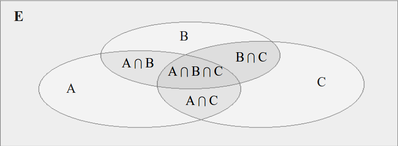

## Enfoques para el cálculo de probabilidades

- Clásico:

$$\begin{equation*}
P(A)=\frac{{n_A}}{n}
\end{equation*}$$

- Frecuentista:

$$\begin{equation*}
P(A)=\frac{{Número\ de\ veces\ que\ se\ presentó\ A}}{Número\ de\ veces\ que\ se\ observó\ el\ experimento}
\end{equation*}$$

- Subjetivo:

$$P(A)\ =\ Criterio\ de\ un\ experto$$

## Ejemplos [G4 - G5]

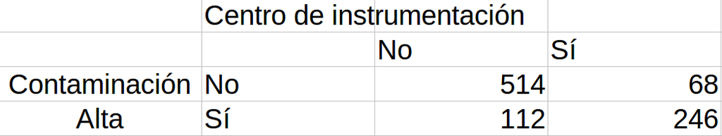

- **Ejemplo 1.4:** en un sistema de producción de hortalizas se detectan tres plagas. El 25% de las plantas tiene la enfermedad A, el 20% B y el 30% C. El 12% la A y B, el 10% la A y C, el 11% B y C y el 5% tiene las tres enfermedades. Obtener:
  - El diagrama de Venn para representar el enunciado.
  - La probabilidad de que una planta posea alguna de las enfermedades. (**Rta: 0.47**)
  - La probabilidad de que una planta posea la enfermedad A pero no la B. (**Rta: 0.13**)
  - La probabilidad de que una planta posea la enfermedad B y C pero no la A. (**Rta: 0.06**)
- **Ejemplo 1.5:** se tiene un lote de 200 animales, de los cuales 88 requieren se vacunados y lo están, 28 necesitan la vacuna pero no lo están, 4 no necesitan la vacuna pero están vacunados, 80 no necesitan la vacuna y no están vacunados. Determine las probabilidades para los siguientes eventos:
  - El animal requiere ser vacunado (**Rta: 0.58**)
  - El animal requiere ser vacunado pero no lo está (**Rta: 0.14**)
  - El animal está vacunado, sea que lo requiera o no. (**Rta: 0.46**)

# Probabilidad condicional

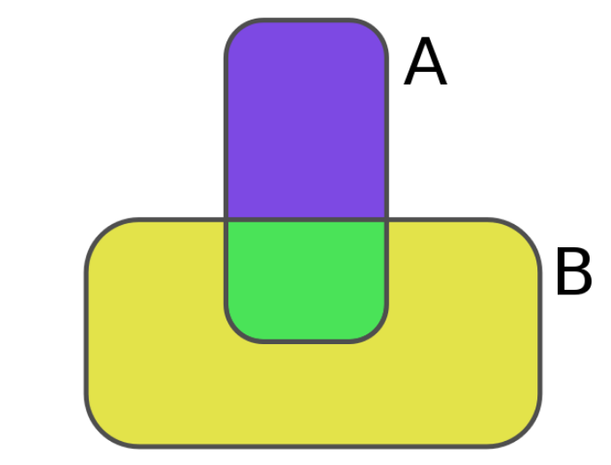

Para dos eventos $A$ y $B$, con $P(B) \geq 0$,

$$\begin{equation*}
P(A|B)=\frac{{P(A \cap B)}}{P(B)}=> Probabilidad\ de\ que\ suceda\ A,\ dado\ que\ ya\ sucedió\ B
\end{equation*}$$

**Nota:** $P(A|B)$ no representa lo mismo que $P(B|A)$.

Las probabilidades condicionales, satisfaces los siguientes axiomas:

- $P(\Omega|B)=1$
- $P[(A \cup C)|B]=P(A|B)+P(C|B)$, si y solo si $P(A \cap C)=\emptyset$

## Ejemplos [G4 - G5]

- **Ejemplo 1.6:** se realizó una encuesta con la finalidad de determianr hábitos de lectura en hombres y mujeres, el resultado se resume en la siguiente tabla:

| Género | Le gusta leer | No le gusta leer | Total |
| --- | --- | --- | --- |
| Hombre | 40 | 20 | 60 |
| Mujer | 50 | 10 | 60 |
| Total | 90 | 30 | 120 |

# Probabilidad de la intersección (regla de la multiplicación)

Contribuye al cálculo de probabilidades de dos eventos simultáneos. Si $A$ y $B$ son dos eventos cualquiera (dependientes) en un espacio muestral $S$ y $P(A) \neq 0$, entonces:
$$P(A \cap B)=P(A)P(B|A)$$

## Ejemplos [G4 - G5]

- **Ejemplo 1.8:** la urna A contiene cuatro bolas rojas y tres azules, mientras que la urna B contiene ocho bolas rojas y dos azules. Se toma un bola de la urna A (sin ver su color) y se deposita en la urna B. Calcular la probabilidad de que ambas bolas elegidas de las urnas sean rojas. **Rta: 0.4675**
- **Ejemplo 1.9:** de una baraja estándar de 52 cartas, sea $A$ el evento de sacar un As en la primera extracción y $B$ sacar un As en la segunda extracción. Calcular la probabilidad de sacar dos Ases en dos extracciones sin devolver la carta extraída. **Rta: 0.004521**

# Teorema de probabilidad total

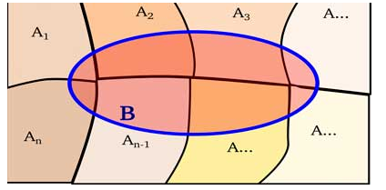

El teorema o regla de la probabilidad total, permite obtener probabilidades marginales o de eventos simples en función de los elementos de una partición. Diremos que si $B_1,B_2,...,B_k$ son eventos que constituyen una **partición** $B_i \cap B_j = \emptyset\ \wedge\ \ \bigcup_{i=1}^{k} B_i=S$, entonces:
$$P(A)=P(A \cap B_1)+P(A\cap B_2)+P(A\cap B_3)+...+P(A\cap B_k)$$

## Ejemplos [G4 - G5]

- **Ejemplo 1.10:** una empresa del sector agropecuario recarga sus extintores para incendios con tres empresas diferentes A, B y C. De registros históricos se sabe que el porcentaje de recargas defectuosas de A, B y C son 3%, 4% y 6%, respectivamente. El porcentaje de recargas realizadas por la empresa en cada una de las empresas ha sido 35%, 45% y 20% para A, B y C, respectivamente. El día de ayer se recibió un extintos recargado pero se desconoce la procedencia. ¿Cuál es la probabilidad de que esté defectuoso? **Rta: 0.0405**
- **Ejemplo 1.11:** se registran datos para el uso o no de gafas de sol en hombres y mujeres. Se tiene que de 17 hombres 5 utilizan gafas y de 20 mujeres 8 utilizan gafas. Obtener:
  - La probabilidad de elegir una persona al azar y que use gafas. **Rta: 0.3513**
  - La probabilidad de elegir una persona al azar y que no use gafas. **Rta: 0.6486**

# Teorema de Bayes

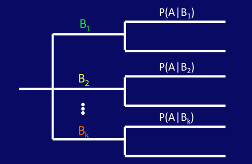

Se usa para responder preguntas de tipo **condicional**. Diremos que si $B_1,B_2,...,B_k$ son eventos que constituyen una **partición** del espacio muestral $S$ con $P(B) \geq 0,\ para\ i=1,2,...,k$, entonces para cualquier evento $A$ en $S$ tal que $P(A) \geq 0$, se tiene:

- Causa $B_r$
- Efecto $A$
- $P(B_r|A)$ dado que se observó el efecto $A$, cuál es la probabilidad de que la causa haya sido $B_r$.

$$\begin{equation*}
P(B_r|A)=\frac{{P(B_r)P(A|B_r)}}{\sum\nolimits_{i=1}^k P(B_i)P(A|B_r)}=\frac{{P(B_r \cap A)}}{P(B)}
\end{equation*}$$

## Ejemplos [G4 - G5]

- **Ejemplo 1.12:** hay dos métodos de capacitación en una empresa. El porcentaje de fracaso del método A es 20% y el de B 10%; sin embargo, como el método B es más costoso se aplica solamente el 30% del tiempo (el otro 70% se emplea A). Un trabajador recibió la capacitación con uno de los métodos pero **no aprendió la destreza**. ¿Cuál es la probabilidad de que el trabajador haya sido capacitado a través del método A? **Rta: 0.8235**
- **Ejemplo 1.13:** los clientes de una empresa se encargan de evaluar los diseños preliminares de varios productos. Por registros históricos, se sabe que en el pasado, el 95% de los productos con mayor éxito en el mercado recibieron buenas evaluaciones, el 60% de los productos con éxito moderado recibieron buenas evaluaciones y el 10% de los productos con poco éxito recibieron buenas evaluaciones. Además, el 40% de los productos han tenido mayor éxito, el 35% éxito modera y el 25% una baja aceptación. A partir de la información, obtener:
  - Si un nuevo diseño obtiene una buena evaluación, ¿cuál es la probabilidad de que se convierta en un producto de gran éxito? **Rta: 0.6178**
  - Si un producto no obtiene una buena evaluación, ¿cuál es la probabilidad de que se convierta en un producto de gran éxito? **Rta: 0.0519**

# Independencia de eventos

Dos eventos $A$ y $B$ son independientes si y sólo si $P(A|B)=P(A)$. Indica que el evento $B$ no “afecta” la aparición del evento $A$.

- **Proposición:** $A$ y $B$ son independenties si y solo si
  $$P(A \cap B) = P(A)P(B)$$

## Ejemplo [G4 - G5]

- **Ejemplo 1.14:** si se lanza un dado de seis caras y una moneda ¿cuál es la probabilidad de que se obtenga un 4 en el dado y un sello en la moneda? **Rta: 0.083**

# Resumen

| Item | Fórmula |
| --- | --- |
| Regla de la multiplicación (conteo) | $n_1\ * n_2\ *...*n_k$ |
| Combinaciones | ${n \choose r}=\frac{{n!}}{r!(n-r)!}$ |
| Permutaciones | ${n \choose r}=\frac{{n!}}{(n-r)!}$ |
| Regla de la adición | $P(A \cup B)=P(A)+P(B)-P(A \cap B)$ |
| Probabilidad Total | $P(A)=P(A \cap B_1)+P(A\cap B_2)+P(A\cap B_3)+...+P(A\cap B_k)$ |
| Independencia de eventos | $P(A \cap B) = P(A)P(B)$ |

- **Probabilidad condicional:** $P(A|B)=\frac{{P(A\cap B)}}{P(B)}$
- **Regla de la multiplicación (probabilidad):** $P(A \cap B)=P(A)P(B|A)$
- **Teorema de Bayes:** $P(B_r|A)=\frac{{P(B_r)P(A|B_r)}}{\sum\nolimits_{i=1}^k P(B_i)P(A|B_r)}=\frac{{P(B_r \cap A)}}{P(B)}$